# IODS course project

# 3 Logistic regression

## Data

### Task 2: Reading and describing the data

```r
alc <- read.table("data/alc.csv", sep = ",", header = T)
```

The data is Student Performance Data Set from UCI Machine Learning Repository. It approaches student achievement in secondary education of two Portuguese schools. The data attributes include student grades, demographic, social and school related features) and it was collected by using school reports and questionnaires. Two datasets are provided regarding the performance in two distinct subjects: Mathematics (mat) and Portuguese language (por). Full description of the original data can be found [here](https://archive.ics.uci.edu/ml/datasets/Student+Performance).

The two datasets have been merged using several variables as identifiers to combine individual students information: school, sex, age, address, family size, parents’ cohabitation status, parents’ education and job, reason to choose school, attendance to school nursery, and home internet access. If the student had answered to the same question on both questionnaires, the the rounded average was calculated. If the question was non-numeric, the answer on Mathematics performance dataset was used.

#### Variables

```
##  [1] X          school     sex        age        address    famsize
##  [7] Pstatus    Medu       Fedu       Mjob       Fjob       reason
## [13] nursery    internet   guardian   traveltime studytime  failures
## [19] schoolsup  famsup     paid       activities higher     romantic
## [25] famrel     freetime   goout      Dalc       Walc       health
## [31] absences   G1         G2         G3         alc_use    high_use
```

**Information about variables used in analyses:**

| *sex* | student’s sex (binary: ‘F’ - female or ‘M’ - male) |
| --- | --- |
| *Medu* | mother’s education (numeric: 0 none, 1 primary education (4th grade), 2 5th to 9th grade, 3 secondary education or 4 higher education) |
| *failures* | number of past class failures (numeric: n if 1<=n<3, else 4) |
| *absences* | number of school absences (numeric: from 0 to 93) |

## Hypotheses

#### Task 3: Choosing the variables and presenting hypotheses

The purpose of my analysis is to study the relationships between high/low alcohol consumption and students’ demographic, social, and school-realted characetristics.

1. Student’s sex: Boys and young men usually consume more alcohol compared to girls or young women.
2. Mother’s education: Parents’ education has been found to be a significant predictor of different social outcomes and well-being. Families with higher education require less support from sociaty in general. Differences in education level might also reflect differences in parents’ own behavior, values and parental support.
3. Failure: Difficulties stack up and failures might lead to disaffection towards school, which in turn might lead to valuing other activities and social circles that accept or encourage alcohol consumption.
4. Absences: Absences might be indications of disaffection and negative attitudes towards school, or other problems in life.

## Exploring variables

### Task 4: Exploring the chosen variables numerically and graphically

```r
library(tidyverse); library(psych); library(knitr); library(kableExtra)
```

```r
describe(alc[, c("sex", "Medu", "failures", "absences", "G3")]) %>% kable(digits = 3, caption = "<b>Descriptives of chosen variables</b>") %>% kable_styling(bootstrap_options = c("striped", "hover"))
```

**Descriptives of chosen variables**

|  | vars | n | mean | sd | median | trimmed | mad | min | max | range | skew | kurtosis | se |
| --- | --- | --- | --- | --- | --- | --- | --- | --- | --- | --- | --- | --- | --- |
| sex* | 1 | 382 | 1.482 | 0.500 | 1 | 1.477 | 0.000 | 1 | 2 | 1 | 0.073 | -2.000 | 0.026 |
| Medu | 2 | 382 | 2.806 | 1.086 | 3 | 2.892 | 1.483 | 0 | 4 | 4 | -0.384 | -1.037 | 0.056 |
| failures | 3 | 382 | 0.202 | 0.583 | 0 | 0.033 | 0.000 | 0 | 3 | 3 | 3.034 | 8.689 | 0.030 |
| absences | 4 | 382 | 4.500 | 5.463 | 3 | 3.536 | 2.965 | 0 | 45 | 45 | 3.187 | 16.186 | 0.279 |
| G3 | 5 | 382 | 11.458 | 3.310 | 12 | 11.631 | 2.965 | 0 | 18 | 18 | -0.459 | 0.180 | 0.169 |

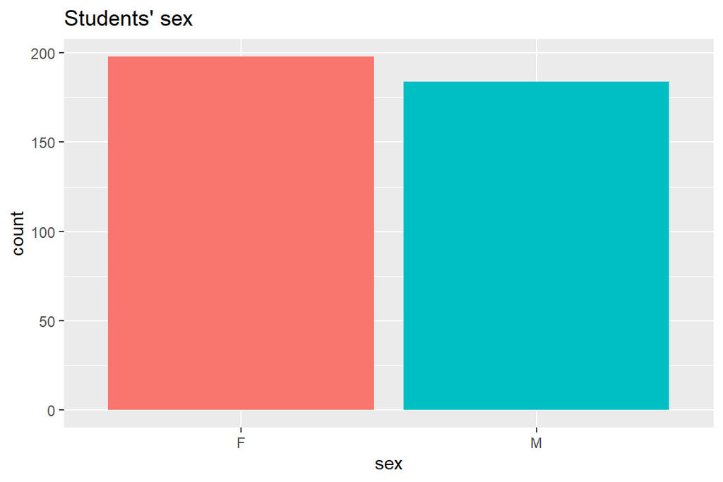

```r
p1 <- ggplot(alc, aes(x = sex, fill = sex))
p1 + geom_bar() + theme(legend.position = "none") + ggtitle("Students' sex")
```

```r
alc %>% count(sex) %>% kable(caption = "<b>Sex of students</b>") %>% kable_styling(bootstrap_options = c("striped", "hover"), full_width = F, position = "left")  %>%  column_spec(2, width = "15em")
```

**Sex of students**

| sex | n |
| --- | --- |
| F | 198 |
| M | 184 |

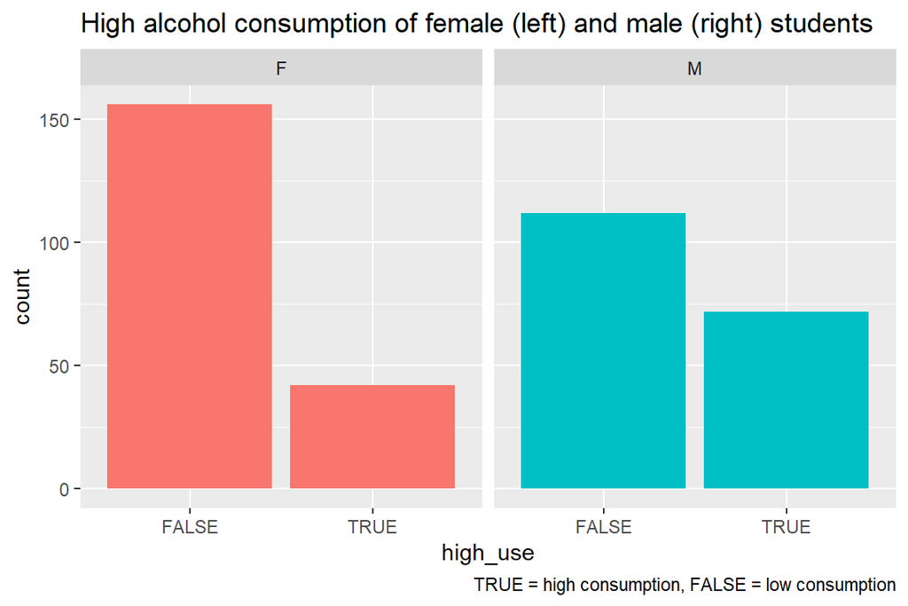

```r
p2 <- ggplot(alc, aes(x = high_use, fill = sex))
p2 + geom_bar() + theme(legend.position = "none") + facet_wrap(~sex) +
  labs(title = "High alcohol consumption of female (left) and male (right) students",
       caption = "TRUE = high consumption, FALSE = low consumption")
```

```r
alc %>%
  group_by(high_use, sex)%>%
  summarise(n=n())%>%
  spread(sex, n) %>%
  kable(caption = "<b>High use by students' sex crosstabulated</b>") %>%
  kable_styling(bootstrap_options = c("striped", "hover"))
```

**High use by students’ sex crosstabulated**

| high_use | F | M |
| --- | --- | --- |
| FALSE | 156 | 112 |
| TRUE | 42 | 72 |

**Mother’s education**

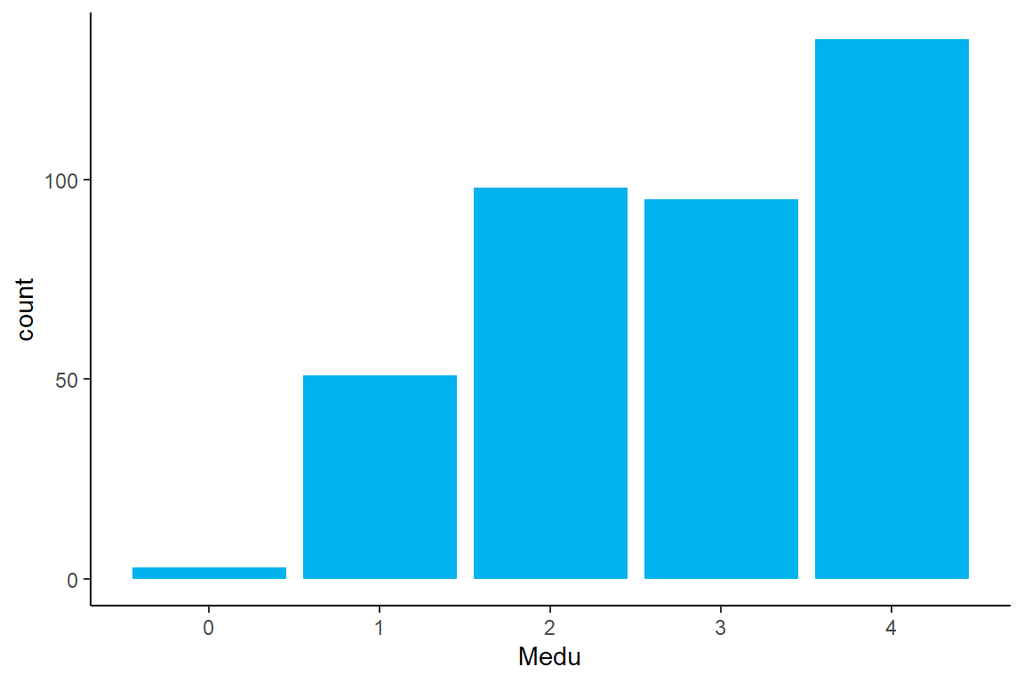

```r
p3 <- ggplot(alc, aes(x = Medu))
p3 + geom_bar(fill = "deepskyblue2") + theme_classic()
```

```r
alc %>%
  group_by(high_use, Medu)%>%
  summarise(n=n())%>%
  spread(Medu, n) %>%
  kable(caption = "<b>High use by mother's education crosstabulated</b>") %>%
  kable_styling(bootstrap_options = c("striped", "hover"))
```

**High use by mother’s education crosstabulated**

| high_use | 0 | 1 | 2 | 3 | 4 |
| --- | --- | --- | --- | --- | --- |
| FALSE | 1 | 33 | 80 | 59 | 95 |
| TRUE | 2 | 18 | 18 | 36 | 40 |

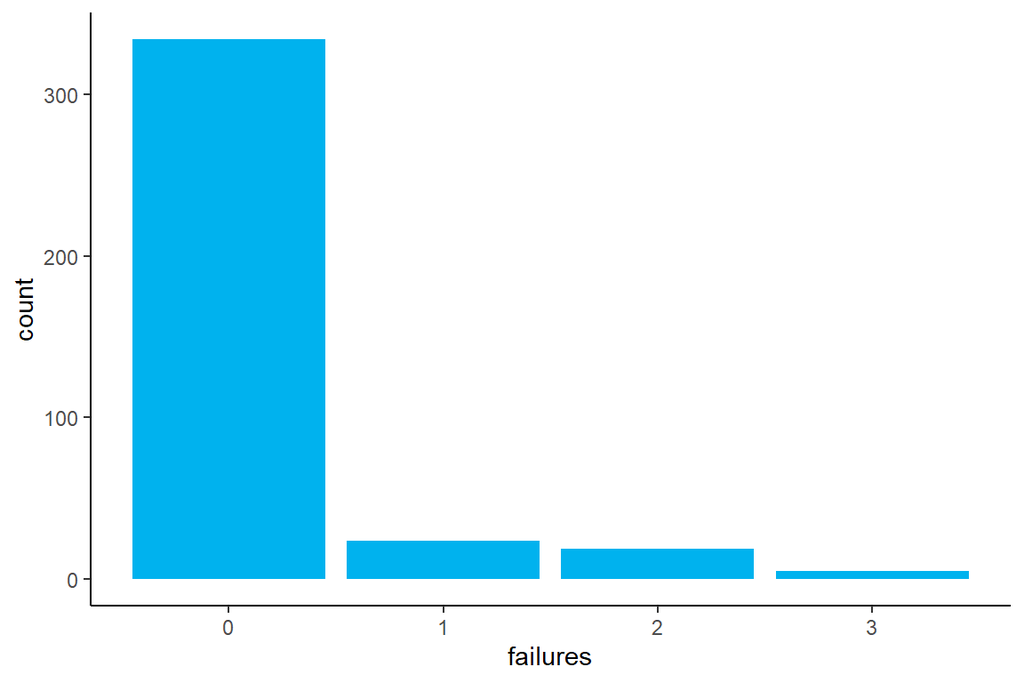

```r
p3 <- ggplot(alc, aes(x = failures))
p3 + geom_bar(fill = "deepskyblue2") + theme_classic()
```

```r
alc %>%
  group_by(high_use, failures)%>%
  summarise(n=n())%>%
  spread(failures, n) %>%
  kable(caption = "<b>High use by mother's education crosstabulated</b>") %>%
  kable_styling(bootstrap_options = c("striped", "hover"))
```

| high_use | 0 | 1 | 2 | 3 |
| --- | --- | --- | --- | --- |
| FALSE | 244 | 12 | 10 | 2 |
| TRUE | 90 | 12 | 9 | 3 |

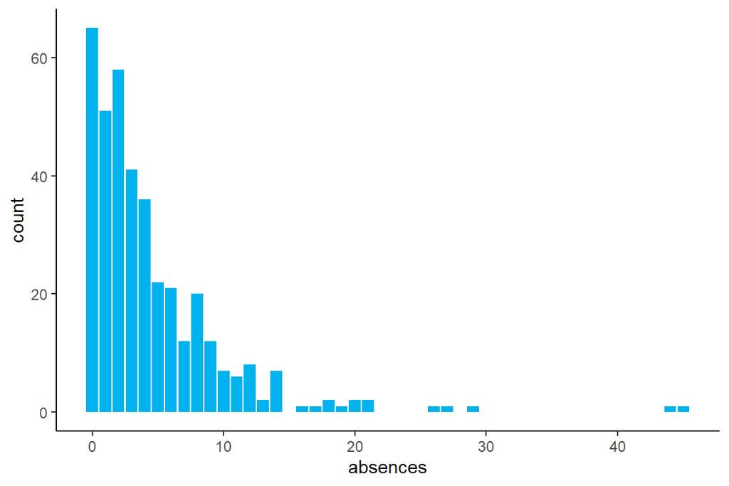

```r
p4 <- ggplot(alc, aes(x = absences))
p4 + geom_bar(fill = "deepskyblue2") + theme_classic()
```

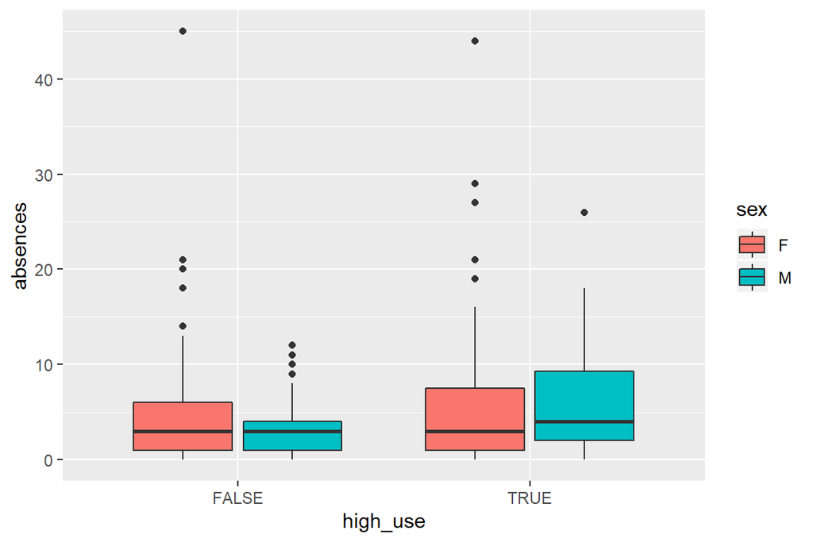

```r
px <- ggplot(alc, aes(x = high_use, y = absences, fill = sex))
px + geom_boxplot()
```

```r
alc %>% group_by(sex, high_use) %>% summarise(count = n(), mean_absences = mean(absences)) %>% kable(digits = 2) %>%
  kable_styling(bootstrap_options = c("striped", "hover"))
```

| sex | high_use | count | mean_absences |
| --- | --- | --- | --- |
| F | FALSE | 156 | 4.22 |
| F | TRUE | 42 | 6.79 |
| M | FALSE | 112 | 2.98 |
| M | TRUE | 72 | 6.12 |

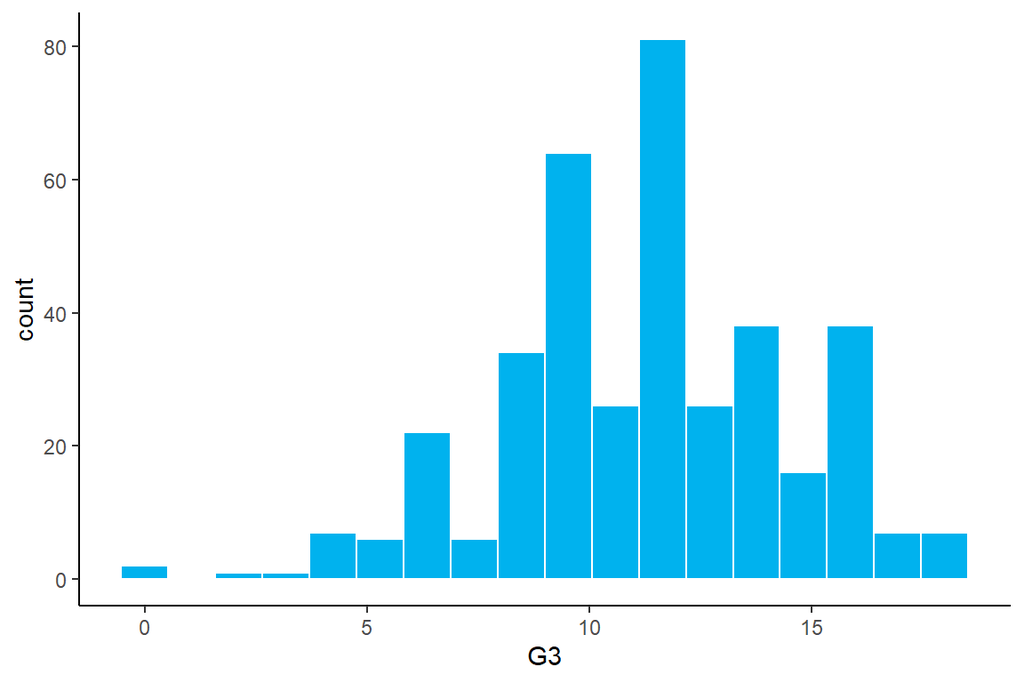

```r
p4 <- ggplot(alc, aes(x = G3))
p4 + geom_histogram(color = "white", fill = "deepskyblue2", bins=18) + theme_classic()
```

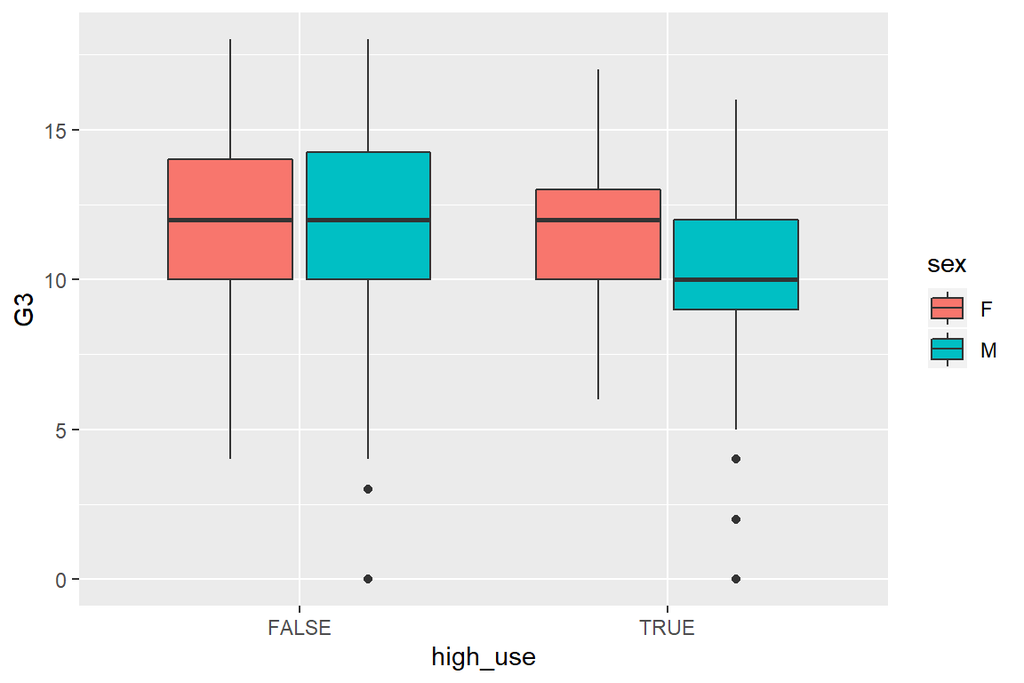

```r
p5 <- ggplot(alc, aes(x = high_use, y = G3, fill = sex))
p5 + geom_boxplot()
```

```r
alc %>% group_by(sex, high_use) %>% summarise(count = n(), mean_grade = mean(G3)) %>% kable(digits = 3) %>%
  kable_styling(bootstrap_options = c("striped", "hover"))
```

| sex | high_use | count | mean_grade |
| --- | --- | --- | --- |
| F | FALSE | 156 | 11.397 |
| F | TRUE | 42 | 11.714 |
| M | FALSE | 112 | 12.205 |
| M | TRUE | 72 | 10.278 |

## Logistic Regression Model

### Task 5: Using logistic regression to statistically explore the relationships

```r
# Fitting the logistic regression
m <- glm(high_use ~ Medu + failures + absences + sex, data = alc, family = "binomial")

# Summary of the model
summary(m)
```

```
##
## Call:
## glm(formula = high_use ~ Medu + failures + absences + sex, family = "binomial",
##     data = alc)
##
## Deviance Residuals:
##     Min       1Q   Median       3Q      Max
## -2.1839  -0.8371  -0.6004   1.1004   2.0266
##
## Coefficients:
##              Estimate Std. Error z value Pr(>|z|)
## (Intercept) -1.916369   0.384473  -4.984 6.22e-07 ***
## Medu         0.005038   0.116739   0.043  0.96558
## failures     0.453431   0.199383   2.274  0.02296 *
## absences     0.093094   0.023125   4.026 5.68e-05 ***
## sexM         0.939703   0.244341   3.846  0.00012 ***
## ---
## Signif. codes:  0 '***' 0.001 '**' 0.01 '*' 0.05 '.' 0.1 ' ' 1
##
## (Dispersion parameter for binomial family taken to be 1)
##
##     Null deviance: 465.68  on 381  degrees of freedom
## Residual deviance: 424.40  on 377  degrees of freedom
## AIC: 434.4
##
## Number of Fisher Scoring iterations: 4
```

```r
# Computing odds ratios and confidence intervals
OR <- coef(m) %>% exp
CI <- confint(m) %>% exp
# Printing out the odds ratios with their confidence intervals
cbind(OR, CI) %>% kable(digits = 3, caption = "Logistic regression model predicting high alcohol consumption with class mother's education, class failures, absences, and student's sex") %>%  kable_styling(bootstrap_options = c("striped", "hover"))
```

Logistic regression model predicting high alcohol consumption with class mother’s education, class failures, absences, and student’s sex

|  | OR | 2.5 % | 97.5 % |
| --- | --- | --- | --- |
| (Intercept) | 0.147 | 0.067 | 0.306 |
| Medu | 1.005 | 0.800 | 1.266 |
| failures | 1.574 | 1.068 | 2.346 |
| absences | 1.098 | 1.051 | 1.151 |
| sexM | 2.559 | 1.594 | 4.163 |

As expected, class failures, school absences, and student’s sex predict higher alcohol consumption. However, mother’s education doesn’t seem to predict alcohol consumption.

## Predictiven power

### Task 6: Explore the predictive power of the model

```r
# predict() the probability of high_use
probabilities <- predict(m, type = "response")

# add the predicted probabilities to 'alc'
alc <- mutate(alc, probability = probabilities)

# use the probabilities to make a prediction of high_use
alc <- mutate(alc, prediction = probability > 0.5)

# see the last ten original classes, predicted probabilities, and class predictions
select(alc, Medu, failures, absences, sex, high_use, probability, prediction) %>% tail(10)
```

```
##     Medu failures absences sex high_use probability prediction
## 373    1        1        0   M    FALSE   0.3732740      FALSE
## 374    4        1        7   M     TRUE   0.5370760       TRUE
## 375    2        0        1   F    FALSE   0.1402520      FALSE
## 376    4        0        6   F    FALSE   0.2078966      FALSE
## 377    2        1        2   F    FALSE   0.2198273      FALSE
## 378    3        0        2   F    FALSE   0.1525078      FALSE
## 379    1        2        2   F    FALSE   0.3061289      FALSE
## 380    1        0        3   F    FALSE   0.1635500      FALSE
## 381    3        0        4   M     TRUE   0.3568241      FALSE
## 382    3        0        2   M     TRUE   0.3153200      FALSE
```

```r
# tabulate the target variable versus the predictions
table(high_use = alc$high_use, prediction = alc$prediction)
```

```
##         prediction
## high_use FALSE TRUE
##    FALSE   259    9
##    TRUE     84   30
```

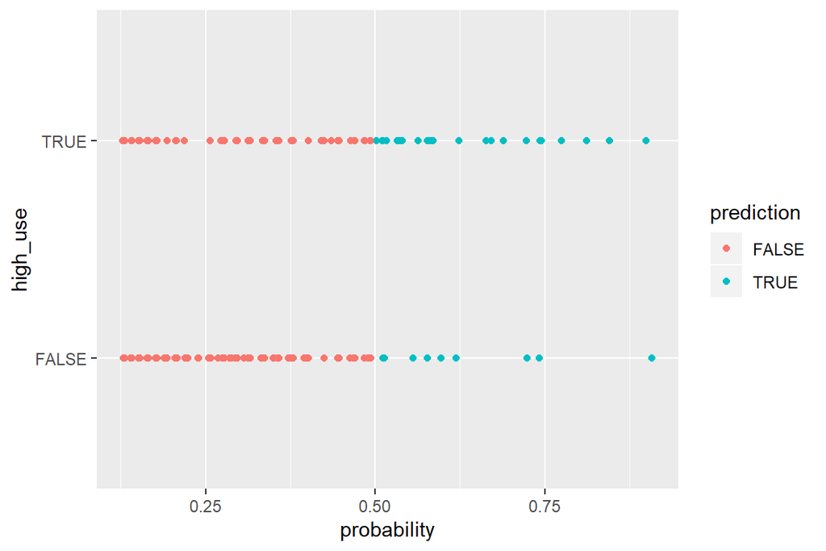

```r
# initialize a plot of 'high_use' versus 'probability' in 'alc'
g <- ggplot(alc, aes(x = probability, y = high_use, col = prediction))

# define the geom as points and draw the plot
g + geom_point()
```

```r
# tabulate the target variable versus the predictions
table(high_use = alc$high_use, prediction = alc$prediction) %>% prop.table() %>% addmargins()
```

```
##         prediction
## high_use      FALSE       TRUE        Sum
##    FALSE 0.67801047 0.02356021 0.70157068
##    TRUE  0.21989529 0.07853403 0.29842932
##    Sum   0.89790576 0.10209424 1.00000000
```